# Initial Korean covid 19

Julian Garcia

November 17, 2026

Data are from the Patient_Info dataset from South Korea 1 Jan to 1 May 2020. These data were retrieved from a downloadable zip file from kaggle.

Some of the data were uncoded for sex - sex must be just male or female. 77 of the data entries were coded sex as blank, so we omit these. State of a patient must be died or alive - we adjust that as well. This is done in the mutate function.

Variables of interest: sex, result

Research Question: - Is dying independent of sex?

# Introduction

The purpose of this study is to determine whether a patient’s sex is related to their likelihood of dying from COVID-19. We will be using data collected from COVID-19 patients in South Korea between January 1 and May 1, 2020. The two variables we are looking at are sex (male or female) and patient result (alive or died). By comparing these two variables, we want to see whether there is a significant relationship between sex and the recorded outcome.

**Null Hypothesis (H₀):** Sex and COVID-19 death outcomes are independent. This means that the proportion of patients who died is the same for males and females.

**Alternative Hypothesis (Hₐ):** Sex and COVID-19 death outcomes are not independent. This means that the proportion of patients who died is different between males and females.

We will use a significance level of 0.05 to determine whether there is enough statistical evidence to reject the null hypothesis.

# Data Results

```r
table(kRdata$sex, kRdata$result)
```

```
##
##          alive dead
##   female  1831   25
##   male    1411   44
```

Looking at the table, we can see that there were 3,311 patients in the dataset. Of these patients, 1,856 were female and 1,455 were male. There were 25 deaths among female patients compared to 44 deaths among male patients. Even though there were more females in the dataset, males had more recorded deaths. This suggests that sex might be related to COVID-19 death outcomes, but we still need to perform a statistical test to determine whether the difference is significant.

## Graphical results

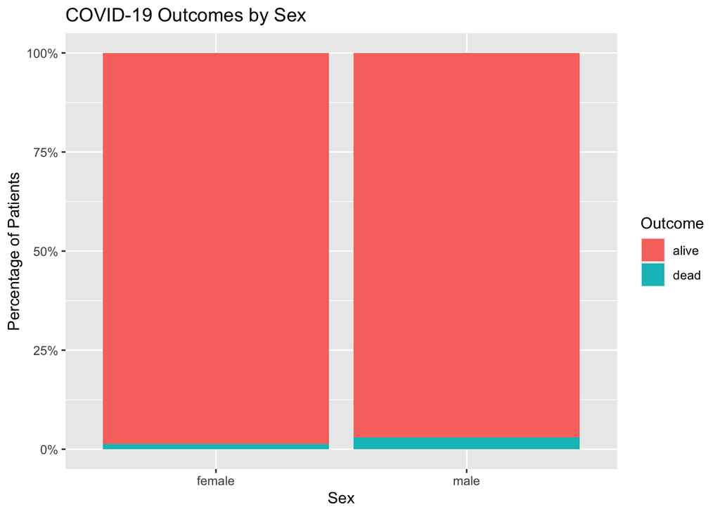

```r
ggplot(kRdata, aes(x = sex, fill = result)) +
  geom_bar(position = "fill") +
  scale_y_continuous(labels = scales::percent) +
  labs(
    title = "COVID-19 Outcomes by Sex",
    x = "Sex",
    y = "Percentage of Patients",
    fill = "Outcome"
  )
```

Looking at the bar graph, we can see that the majority of both male and female patients were recorded as alive. However, males had a slightly higher percentage of deaths compared to females. About 3.02% of male patients died, while only 1.35% of female patients died. Although the difference looks small on the graph, males had more than twice the recorded death percentage of females. This suggests that there might be a relationship between sex and COVID-19 death outcomes, but we still need to perform a statistical test to see if the difference is significant.

## Numerical results

```r
prop.table(table(kRdata$sex, kRdata$result), margin = 1)
```

```
##
##          alive  dead
##   female 0.987 0.013
##   male   0.970 0.030
```

Looking at the numerical results, we can see that about 98.7% of female patients were alive compared to 97.0% of male patients. For deaths, about 1.3% of females died compared to 3.0% of males. This shows that male patients had a higher proportion of deaths, even though there were fewer males in the dataset. The difference in death percentages suggests that sex might have a relationship with COVID-19 outcomes. However, we still need to test whether this difference is statistically significant.

## Inferential results

```r
chisq.test(table(kRdata$sex, kRdata$result))
```

```
##
##  Pearson's Chi-squared test with Yates' continuity correction
##
## data:  table(kRdata$sex, kRdata$result)
## X-squared = 10, df = 1, p-value = 0.001
```

The chi-square test was used to determine whether sex and COVID-19 outcomes are independent. The results showed a chi-square value of 10 with 1 degree of freedom and a p-value of 0.001. Since the p-value is less than our significance level of 0.05, we reject the null hypothesis. This means there is a statistically significant relationship between sex and COVID-19 outcomes. Based on our data, males had a higher percentage of deaths (3.0%) compared to females (1.3%).

# Conclusions

The research question for this study was: Is dying from COVID-19 independent of sex? Based on the data collected from South Korea, we found that males had a higher percentage of deaths (3.0%) compared to females (1.3%). The chi-square test gave us a p-value of 0.001, which is less than our significance level of 0.05. Therefore, we reject the null hypothesis. This means that dying from COVID-19 is not independent of sex in this dataset. Overall, the results suggest that males had a higher death rate than females among the patients studied. However, other factors could have influenced these results.